# IE 582-Hw 4

Kadir Ahmet Aksu

29 01 2021

##Data Set Information:

There are two files: (1) train.csv contains 81 features extracted from 21263 superconductors along with the critical temperature in the 82nd column, (2) unique_m.csv contains the chemical formula broken up for all the 21263 superconductors from the train.csv file. The last two columns have the critical temperature and chemical formula. The original data comes from [Web Link] which is public. The goal here is to predict the critical temperature based on the features extracted.

###Data Set Information:

The data set consists of the expression levels of 77 proteins/protein modifications that produced detectable signals in the nuclear fraction of cortex. There are 38 control mice and 34 trisomic mice (Down syndrome), for a total of 72 mice. In the experiments, 15 measurements were registered of each protein per sample/mouse. Therefore, for control mice, there are 38x15, or 570 measurements, and for trisomic mice, there are 34x15, or 510 measurements. The dataset contains a total of 1080 measurements per protein. Each measurement can be considered as an independent sample/mouse.

The eight classes of mice are described based on features such as genotype, behavior and treatment. According to genotype, mice can be control or trisomic. According to behavior, some mice have been stimulated to learn (context-shock) and others have not (shock-context) and in order to assess the effect of the drug memantine in recovering the ability to learn in trisomic mice, some mice have been injected with the drug and others have not.

Classes: c-CS-s: control mice, stimulated to learn, injected with saline (9 mice) c-CS-m: control mice, stimulated to learn, injected with memantine (10 mice) c-SC-s: control mice, not stimulated to learn, injected with saline (9 mice) c-SC-m: control mice, not stimulated to learn, injected with memantine (10 mice)

t-CS-s: trisomy mice, stimulated to learn, injected with saline (7 mice) t-CS-m: trisomy mice, stimulated to learn, injected with memantine (9 mice) t-SC-s: trisomy mice, not stimulated to learn, injected with saline (9 mice) t-SC-m: trisomy mice, not stimulated to learn, injected with memantine (9 mice)

The aim is to identify subsets of proteins that are discriminant between the classes.

###Data Set Information:

The database consists of the multi-spectral values of pixels in 3x3 neighbourhoods in a satellite image, and the classification associated with the central pixel in each neighbourhood. The aim is to predict this classification, given the multi-spectral values. In the sample database, the class of a pixel is coded as a number.

The Landsat satellite data is one of the many sources of information available for a scene. The interpretation of a scene by integrating spatial data of diverse types and resolutions including multispectral and radar data, maps indicating topography, land use etc. is expected to assume significant importance with the onset of an era characterised by integrative approaches to remote sensing (for example, NASA’s Earth Observing System commencing this decade). Existing statistical methods are ill-equipped for handling such diverse data types. Note that this is not true for Landsat MSS data considered in isolation (as in this sample database). This data satisfies the important requirements of being numerical and at a single resolution, and standard maximum-likelihood classification performs very well. Consequently, for this data, it should be interesting to compare the performance of other methods against the statistical approach.

One frame of Landsat MSS imagery consists of four digital images of the same scene in different spectral bands. Two of these are in the visible region (corresponding approximately to green and red regions of the visible spectrum) and two are in the (near) infra-red. Each pixel is a 8-bit binary word, with 0 corresponding to black and 255 to white. The spatial resolution of a pixel is about 80m x 80m. Each image contains 2340 x 3380 such pixels.

The database is a (tiny) sub-area of a scene, consisting of 82 x 100 pixels. Each line of data corresponds to a 3x3 square neighbourhood of pixels completely contained within the 82x100 sub-area. Each line contains the pixel values in the four spectral bands (converted to ASCII) of each of the 9 pixels in the 3x3 neighbourhood and a number indicating the classification label of the central pixel. The number is a code for the following classes:

Number Class 1 red soil 2 cotton crop 3 grey soil 4 damp grey soil 5 soil with vegetation stubble 6 mixture class (all types present) 7 very damp grey soil

NB. There are no examples with class 6 in this dataset.

The data is given in random order and certain lines of data have been removed so you cannot reconstruct the original image from this dataset.

In each line of data the four spectral values for the top-left pixel are given first followed by the four spectral values for the top-middle pixel and then those for the top-right pixel, and so on with the pixels read out in sequence left-to-right and top-to-bottom. Thus, the four spectral values for the central pixel are given by attributes 17,18,19 and 20. If you like you can use only these four attributes, while ignoring the others. This avoids the problem which arises when a 3x3 neighbourhood straddles a boundary.

##Data Set Information:

Mining activity was and is always connected with the occurrence of dangers which are commonly called mining hazards. A special case of such threat is a seismic hazard which frequently occurs in many underground mines. Seismic hazard is the hardest detectable and predictable of natural hazards and in this respect it is comparable to an earthquake. More and more advanced seismic and seismoacoustic monitoring systems allow a better understanding rock mass processes and definition of seismic hazard prediction methods. Accuracy of so far created methods is however far from perfect. Complexity of seismic processes and big disproportion between the number of low-energy seismic events and the number of high-energy phenomena (e.g. > 10^4J) causes the statistical techniques to be insufficient to predict seismic hazard. Therefore, it is essential to search for new opportunities of better hazard prediction, also using machine learning methods. In seismic hazard assessment data clustering techniques can be applied (Lesniak A., Isakow Z.: Space-time clustering of seismic events and hazard assessment in the Zabrze-Bielszowice coal mine, Poland. Int. Journal of Rock Mechanics and Mining Sciences, 46(5), 2009, 918-928), and for prediction of seismic tremors artificial neural networks are used (Kabiesz, J.: Effect of the form of data on the quality of mine tremors hazard forecasting using neural networks. Geotechnical and Geological Engineering, 24(5), 2005, 1131-1147). In the majority of applications, the results obtained by mentioned methods are reported in the form of two states which are interpreted as ‘hazardous’ and ‘non-hazardous’. Unbalanced distribution of positive (‘hazardous state’) and negative (‘non-hazardous state’) examples is a serious problem in seismic hazard prediction. Currently used methods are still insufficient to achieve good sensitivity and specificity of predictions. In the paper (Bukowska M.: The probability of rockburst occurrence in the Upper Silesian Coal Basin area dependent on natural mining conditions. Journal of Mining Sciences, 42(6), 2006, 570-577) a number of factors having an effect on seismic hazard occurrence was proposed, among other factors, the occurrence of tremors with energy > 10^4J was listed. The task of seismic prediction can be defined in different ways, but the main aim of all seismic hazard assessment methods is to predict (with given precision relating to time and date) of increased seismic activity which can cause a rockburst. In the data set each row contains a summary statement about seismic activity in the rock mass within one shift (8 hours). If decision attribute has the value 1, then in the next shift any seismic bump with an energy higher than 10^4 J was registered. That task of hazards prediction bases on the relationship between the energy of recorded tremors and seismoacoustic activity with the possibility of rockburst occurrence. Hence, such hazard prognosis is not connected with accurate rockburst prediction. Moreover, with the information about the possibility of hazardous situation occurrence, an appropriate supervision service can reduce a risk of rockburst (e.g. by distressing shooting) or withdraw workers from the threatened area. Good prediction of increased seismic activity is therefore a matter of great practical importance. The presented data set is characterized by unbalanced distribution of positive and negative examples. In the data set there are only 170 positive examples representing class 1.

```r
rm(list = ls())
library(quantreg)
library(data.table)
library(chron)
library(ellipsis)
library(forecast)
library(xts)
library(zoo)
library(stats)
library(dplyr)
library(corrr)
```

```r
library(corrplot)
library(tidyverse)
library(miscTools)
library(cvAUC)
library(pROC)
library(glmnet)
library(jpeg)
require(caret)
library(ggplot2)
library(yardstick)
library(broom)
library(stringr)
library(tidyr)
library(purrr)
library(WRTDStidal)
library(varhandle)
library(parallel)
library(doParallel)
library(ISLR)
library(klaR)
library(e1071)
library(ada)
library(Metrics)
library(ranger)
library(gbm)
setwd("C:/Users/kadir/OneDrive/Masaüstü")


RMSE = function(m, o){
  sqrt(mean((m - o)^2))
}
```

```r
#regression

data1<-read.csv("train1.csv", sep = ",")


data1<-na.omit(data1)
data1<-data.table(data1)
trainregression<-data1[1:15000,]
testregression<-data1[15001:21263,]
testmatrixx1<-as.matrix(testregression[,1:81])
n_folds=10

myGridGlmnet <- expand.grid(alpha= 1, lambda = c(0.20,0.25,0.30,0.35,0.40))
rf_grid=expand.grid(mtry = c(4,6,8,10,12), splitrule = c("variance"),min.node.size = c(5))
tree_grid=expand.grid(cp = c(1:10)/1000)
myGridGbm <- expand.grid(interaction.depth=c(1,3,5), n.trees = (1:3)*100,shrinkage=c(0.01,0.005,0.001), n.minobsinnode=10)

fitControl=trainControl(method = "cv", number = n_folds)

set.seed(1)
penalized_model<- train(critical_temp~.,trainregression, method="glmnet",tuneGrid=myGridGlmnet ,trControl = fitControl)
penalized_model
```

```
## glmnet
##
## 15000 samples
##    81 predictor
##
## No pre-processing
## Resampling: Cross-Validated (10 fold)
## Summary of sample sizes: 13501, 13501, 13501, 13499, 13499, 13500, ...
## Resampling results across tuning parameters:
##
##   lambda  RMSE      Rsquared   MAE
##   0.20    20.45393  0.6671797  16.22816
##   0.25    20.58191  0.6631267  16.37850
##   0.30    20.67983  0.6600699  16.49710
##   0.35    20.78698  0.6566765  16.62441
##   0.40    20.89612  0.6531935  16.75373
##
## Tuning parameter 'alpha' was held constant at a value of 1
## RMSE was used to select the optimal model using the smallest value.
## The final values used for the model were alpha = 1 and lambda = 0.2.
```

```r
rf_fit=train(critical_temp ~ ., data = data.frame(trainregression), method = "ranger",trControl = fitControl, num.trees=500,tuneGrid = rf_grid)
rf_fit
```

```
## Random Forest
##
## 15000 samples
##    81 predictor
##
## No pre-processing
## Resampling: Cross-Validated (10 fold)
## Summary of sample sizes: 13499, 13498, 13500, 13500, 13501, 13500, ...
## Resampling results across tuning parameters:
##
##   mtry  RMSE      Rsquared   MAE
##    4    10.21157  0.9171903  6.196846
##    6    10.19438  0.9174072  6.164031
##    8    10.18167  0.9175858  6.138994
##   10    10.16318  0.9178820  6.126967
##   12    10.16811  0.9177801  6.120472
##
## Tuning parameter 'splitrule' was held constant at a value of variance
##
## Tuning parameter 'min.node.size' was held constant at a value of 5
## RMSE was used to select the optimal model using the smallest value.
## The final values used for the model were mtry = 10, splitrule = variance
##  and min.node.size = 5.
```

```r
tree_fit1=train(critical_temp~ ., data =data.frame(trainregression),method = "rpart", trControl = fitControl, tuneGrid = tree_grid,tuneLength = 1 )
tree_fit1
```

```
## CART
##
## 15000 samples
##    81 predictor
##
## No pre-processing
## Resampling: Cross-Validated (10 fold)
## Summary of sample sizes: 13501, 13500, 13500, 13500, 13500, 13500, ...
## Resampling results across tuning parameters:
##
##   cp     RMSE      Rsquared   MAE
##   0.001  15.14792  0.8173636  10.35436
##   0.002  16.23734  0.7900555  11.38344
##   0.003  16.94241  0.7714087  11.95446
##   0.004  17.50121  0.7560408  12.44158
##   0.005  17.93209  0.7438305  12.85536
##   0.006  18.20003  0.7361315  13.10808
##   0.007  18.56434  0.7254481  13.40176
##   0.008  18.90028  0.7155129  13.73015
##   0.009  18.90028  0.7155129  13.73015
##   0.010  18.98784  0.7128833  13.80214
##
## RMSE was used to select the optimal model using the smallest value.
## The final value used for the model was cp = 0.001.
```

```r
gbm_model = train(critical_temp~.,data=data.frame(trainregression), method = "gbm",tuneGrid= myGridGbm ,trControl = fitControl)
gbm_model
```

```
## Stochastic Gradient Boosting
##
## 15000 samples
##    81 predictor
##
## No pre-processing
## Resampling: Cross-Validated (10 fold)
## Summary of sample sizes: 13500, 13500, 13499, 13501, 13500, 13500, ...
## Resampling results across tuning parameters:
##
##   shrinkage  interaction.depth  n.trees  RMSE      Rsquared   MAE
##   0.001      1                  100      33.78073  0.5008031  29.87217
##   0.001      1                  200      32.36870  0.5237773  28.50358
##   0.001      1                  300      31.13992  0.5410265  27.32675
##   0.001      3                  100      33.40913  0.6420490  29.53031
##   0.001      3                  200      31.62448  0.6534127  27.80699
##   0.001      3                  300      29.98203  0.6711035  26.26069
##   0.001      5                  100      33.23148  0.6944711  29.38917
##   0.001      5                  200      31.29738  0.7036163  27.54919
##   0.001      5                  300      29.55210  0.7164544  25.91981
##   0.005      1                  100      29.10456  0.5690981  25.33146
##   0.005      1                  200      25.75895  0.5960600  21.81932
##   0.005      1                  300      23.93898  0.6134180  19.67463
##   0.005      3                  100      27.21225  0.6868757  23.63814
##   0.005      3                  200      22.73757  0.7118596  19.18224
##   0.005      3                  300      20.26204  0.7344794  16.56825
##   0.005      5                  100      26.59430  0.7304910  23.16609
##   0.005      5                  200      21.73780  0.7517366  18.44959
##   0.005      5                  300      19.02659  0.7716837  15.58116
##   0.010      1                  100      25.74997  0.5957042  21.80565
##   0.010      1                  200      22.74401  0.6394034  18.42549
##   0.010      1                  300      21.23402  0.6681626  16.78184
##   0.010      3                  100      22.71784  0.7116190  19.16835
##   0.010      3                  200      18.86922  0.7480592  15.02604
##   0.010      3                  300      17.46366  0.7690760  13.41829
##   0.010      5                  100      21.71574  0.7518413  18.42247
##   0.010      5                  200      17.46223  0.7860333  13.86353
##   0.010      5                  300      16.00204  0.8050414  12.12077
##
## Tuning parameter 'n.minobsinnode' was held constant at a value of 10
## RMSE was used to select the optimal model using the smallest value.
## The final values used for the model were n.trees = 300, interaction.depth =
##  5, shrinkage = 0.01 and n.minobsinnode = 10.
```

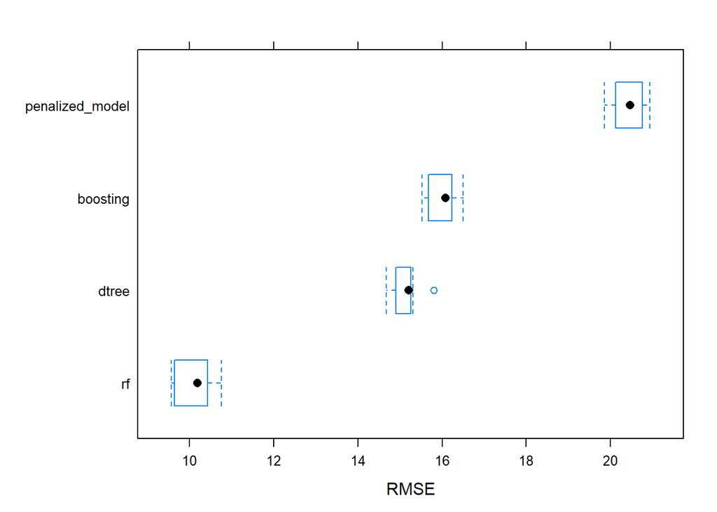

```r
results = resamples(list(penalized_model=penalized_model,dtree=tree_fit1,rf=rf_fit,boosting=gbm_model),metrics='Accuracy')
bwplot(results,metric ="RMSE")
```

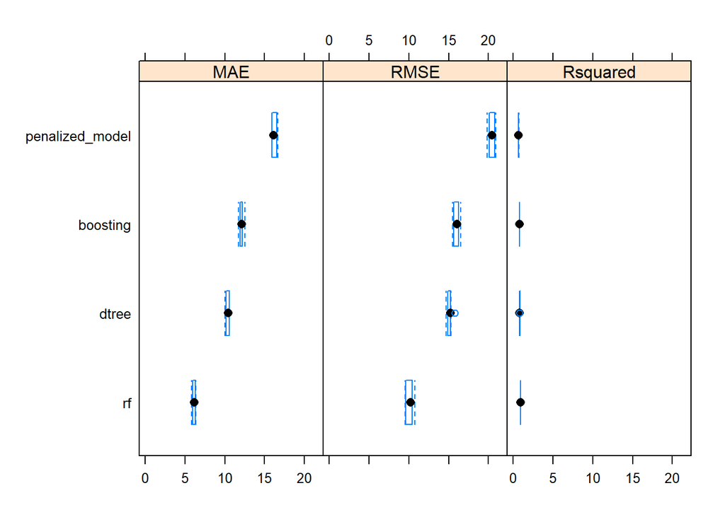

```r
bwplot(results,metrics='Accuracy')
```

```r
testregression[,predpenalized:=predict(penalized_model, testmatrixx1)]
testregression[,predforest:=predict(rf_fit, testmatrixx1)]
testregression[,predtree:=predict(tree_fit1, testmatrixx1)]
testregression[,predgbm:=predict(gbm_model , testmatrixx1)]

mape(testregression$critical_temp,testregression$predpenalized)
```

```
## [1] 8.194666
```

```r
RMSE(testregression$critical_temp,testregression$predpenalized)
```

```
## [1] 14.82855
```

```r
mape(testregression$critical_temp,testregression$predforest)
```

```
## [1] 8.063358
```

```r
RMSE(testregression$critical_temp,testregression$predforest)
```

```
## [1] 11.25054
```

```r
mape(testregression$critical_temp,testregression$predtree)
```

```
## [1] 8.753705
```

```r
RMSE(testregression$critical_temp,testregression$predtree)
```

```
## [1] 13.49042
```

```r
mape(testregression$critical_temp,testregression$predgbm)
```

```
## [1] 14.49565
```

```r
RMSE(testregression$critical_temp,testregression$predgbm)
```

```
## [1] 11.76919
```

##Best method is random forest because it has the lowest RMSE and Mape values.

```r
library("readxl")

data3<-read_excel("Data_Cortex_Nuclear.xls")
data3<-na.omit(data3)



data3<-na.omit(data3)
data3<-data.table(data3)
newdata3<-cbind(data3[,2:78],data3[,82])


sample_size = floor(0.6*nrow(newdata3))
set.seed(777)

## randomly split data in r
picked = sample(seq_len(nrow(newdata3)),size = sample_size)
trainnuclear =newdata3[picked,]
testnuclear =newdata3[-picked,]

testmatrixx2<-as.matrix(testnuclear[,1:77])
n_folds=10
myGridGlmnet <- expand.grid(alpha= 1, lambda = c(0.20,0.25,0.30,0.35,0.40))
fitControl=trainControl(method = "cv",
                        number = n_folds)
set.seed(1)
penalized_model2<- train(class~.,trainnuclear, method="glmnet",tuneGrid=myGridGlmnet ,trControl = fitControl)
penalized_model2
```

```
## glmnet
##
## 331 samples
##  77 predictor
##   8 classes: 'c-CS-m', 'c-CS-s', 'c-SC-m', 'c-SC-s', 't-CS-m', 't-CS-s', 't-SC-m', 't-SC-s'
##
## No pre-processing
## Resampling: Cross-Validated (10 fold)
## Summary of sample sizes: 299, 298, 297, 299, 298, 298, ...
## Resampling results across tuning parameters:
##
##   lambda  Accuracy   Kappa
##   0.20    0.1814476  0.02809989
##   0.25    0.1695626  0.00000000
##   0.30    0.1695626  0.00000000
##   0.35    0.1695626  0.00000000
##   0.40    0.1695626  0.00000000
##
## Tuning parameter 'alpha' was held constant at a value of 1
## Accuracy was used to select the optimal model using the largest value.
## The final values used for the model were alpha = 1 and lambda = 0.2.
```

```r
rf_grid=expand.grid(mtry = c(4,6,8,10,12),
                    splitrule = c("gini","extratrees"),
                    min.node.size = c(5))


rf_fit2=train(class ~ ., data = data.frame(trainnuclear),
              method = "ranger",
              trControl = fitControl, num.trees=500,
              tuneGrid = rf_grid)

rf_fit2
```

```
## Random Forest
##
## 331 samples
##  77 predictor
##   8 classes: 'c-CS-m', 'c-CS-s', 'c-SC-m', 'c-SC-s', 't-CS-m', 't-CS-s', 't-SC-m', 't-SC-s'
##
## No pre-processing
## Resampling: Cross-Validated (10 fold)
## Summary of sample sizes: 299, 298, 297, 297, 298, 298, ...
## Resampling results across tuning parameters:
##
##   mtry  splitrule   Accuracy   Kappa
##    4    gini        0.9909982  0.9896445
##    4    extratrees  0.9909926  0.9896100
##    6    gini        0.9909035  0.9895222
##    6    extratrees  0.9941176  0.9932271
##    8    gini        0.9940285  0.9931218
##    8    extratrees  0.9970588  0.9966102
##   10    gini        0.9940285  0.9931328
##   10    extratrees  0.9970588  0.9966102
##   12    gini        0.9910873  0.9897430
##   12    extratrees  0.9970588  0.9966102
##
## Tuning parameter 'min.node.size' was held constant at a value of 5
## Accuracy was used to select the optimal model using the largest value.
## The final values used for the model were mtry = 8, splitrule = extratrees
##  and min.node.size = 5.
```

```r
tree_grid=expand.grid(cp = c(1:10)/1000)


tree_fit2=train(class~ ., data =data.frame(trainnuclear),
                method = "rpart",
                trControl = fitControl,
                tuneGrid = tree_grid,tuneLength = 1 )

tree_fit2
```

```
## CART
##
## 331 samples
##  77 predictor
##   8 classes: 'c-CS-m', 'c-CS-s', 'c-SC-m', 'c-SC-s', 't-CS-m', 't-CS-s', 't-SC-m', 't-SC-s'
##
## No pre-processing
## Resampling: Cross-Validated (10 fold)
## Summary of sample sizes: 298, 298, 297, 298, 297, 300, ...
## Resampling results across tuning parameters:
##
##   cp     Accuracy   Kappa
##   0.001  0.7880773  0.7564906
##   0.002  0.7880773  0.7564906
##   0.003  0.7880773  0.7564906
##   0.004  0.7880773  0.7564906
##   0.005  0.7790649  0.7462494
##   0.006  0.7790649  0.7462494
##   0.007  0.7790649  0.7462494
##   0.008  0.7790649  0.7462494
##   0.009  0.7790649  0.7463661
##   0.010  0.7790649  0.7463661
##
## Accuracy was used to select the optimal model using the largest value.
## The final value used for the model was cp = 0.004.
```

```r
myGridGbm <- expand.grid(interaction.depth=c(1,3,5), n.trees = (1:3)*100,shrinkage=c(0.01,0.005,0.001), n.minobsinnode=10)


gbm_model2 = train(class~.,data=data.frame(trainnuclear), method = "gbm",tuneGrid= myGridGbm ,trControl = fitControl)
gbm_model2
```

```
## Stochastic Gradient Boosting
##
## 331 samples
##  77 predictor
##   8 classes: 'c-CS-m', 'c-CS-s', 'c-SC-m', 'c-SC-s', 't-CS-m', 't-CS-s', 't-SC-m', 't-SC-s'
##
## No pre-processing
## Resampling: Cross-Validated (10 fold)
## Summary of sample sizes: 298, 298, 299, 298, 298, 296, ...
## Resampling results across tuning parameters:
##
##   shrinkage  interaction.depth  n.trees  Accuracy   Kappa
##   0.001      1                  100      0.6731705  0.6230161
##   0.001      1                  200      0.6943938  0.6474865
##   0.001      1                  300      0.6913635  0.6438701
##   0.001      3                  100      0.8939994  0.8779173
##   0.001      3                  200      0.8907068  0.8741042
##   0.001      3                  300      0.8907908  0.8742438
##   0.001      5                  100      0.8967674  0.8811266
##   0.001      5                  200      0.9089059  0.8950297
##   0.001      5                  300      0.9179968  0.9054764
##   0.005      1                  100      0.7186926  0.6754049
##   0.005      1                  200      0.7700523  0.7346548
##   0.005      1                  300      0.8031457  0.7729375
##   0.005      3                  100      0.9118471  0.8983788
##   0.005      3                  200      0.9389745  0.9296092
##   0.005      3                  300      0.9420048  0.9331123
##   0.005      5                  100      0.9330922  0.9228834
##   0.005      5                  200      0.9420940  0.9332883
##   0.005      5                  300      0.9509175  0.9434307
##   0.010      1                  100      0.7579139  0.7207894
##   0.010      1                  200      0.8213605  0.7941520
##   0.010      1                  300      0.8849136  0.8672832
##   0.010      3                  100      0.9389745  0.9296058
##   0.010      3                  200      0.9539478  0.9469332
##   0.010      3                  300      0.9722416  0.9680226
##   0.010      5                  100      0.9360334  0.9262600
##   0.010      5                  200      0.9540425  0.9470404
##   0.010      5                  300      0.9724254  0.9682491
##
## Tuning parameter 'n.minobsinnode' was held constant at a value of 10
## Accuracy was used to select the optimal model using the largest value.
## The final values used for the model were n.trees = 300, interaction.depth =
##  5, shrinkage = 0.01 and n.minobsinnode = 10.
```

```r
unique(testnuclear$class)
```

```
## [1] "c-CS-m" "c-SC-m" "c-CS-s" "c-SC-s" "t-CS-m" "t-SC-m" "t-CS-s" "t-SC-s"
```

```r
testnuclear[,predpenalized:=predict(penalized_model2, testmatrixx2)]
testnuclear[,predforest:=predict(rf_fit2, testmatrixx2)]
testnuclear[,predtree:=predict(tree_fit2, testmatrixx2)]
testnuclear[,predgbm:=predict(gbm_model2 , testmatrixx2)]


Test_Performances2 <- data.table(
  Glm_Test_ACC=mean(testnuclear$class==testnuclear$predpenalized),
  Dt_Test_ACC =mean(testnuclear$class==testnuclear$predtree) ,
  Forest_Test_ACC =mean(testnuclear$class==testnuclear$predforest),
  SGBM_Test_ACC = mean(testnuclear$class==testnuclear$predgbm)
)

Test_Performances2
```

```
##    Glm_Test_ACC Dt_Test_ACC Forest_Test_ACC SGBM_Test_ACC
## 1:    0.1538462   0.7737557       0.9819005     0.9683258
```

##Best method is random forest for this data. Because it has the highest accuracy rate.The worst one is penalized regression.

```r
dataekstra<-read.csv("sat.tst", sep = " ")

for(i in 1:37){

  dataekstra[,i]<-as.numeric(as.character(dataekstra[,i]))

}

dataekstra<-na.omit(dataekstra)
dataekstra<-data.table(dataekstra)

dataekstra$c37<-as.character(as.numeric(dataekstra$c37))
sample_size = floor(0.8*nrow(dataekstra))
set.seed(777)

picked = sample(seq_len(nrow(dataekstra)),size = sample_size)
trainek =dataekstra[picked,]
testek =dataekstra[-picked,]

testmatrixx4<-as.matrix(testek[,1:36])

n_folds=10
myGridGlmnet <- expand.grid(alpha= 1, lambda = c(0.20,0.25,0.30,0.35,0.40))
fitControl=trainControl(method = "cv",
                        number = n_folds)
set.seed(1)
penalized_model4<- train(c37~.,trainek, method="glmnet",tuneGrid=myGridGlmnet ,trControl = fitControl)
penalized_model4
```

```
## glmnet
##
## 1600 samples
##   36 predictor
##    6 classes: '1', '2', '3', '4', '5', '7'
##
## No pre-processing
## Resampling: Cross-Validated (10 fold)
## Summary of sample sizes: 1440, 1442, 1441, 1438, 1441, 1440, ...
## Resampling results across tuning parameters:
##
##   lambda  Accuracy   Kappa
##   0.20    0.5656008  0.4411032
##   0.25    0.3837009  0.2033333
##   0.30    0.2324972  0.0000000
##   0.35    0.2324972  0.0000000
##   0.40    0.2324972  0.0000000
##
## Tuning parameter 'alpha' was held constant at a value of 1
## Accuracy was used to select the optimal model using the largest value.
## The final values used for the model were alpha = 1 and lambda = 0.2.
```

```r
rf_grid=expand.grid(mtry = c(4,6,8),
                    splitrule = c("gini","extratrees"),
                    min.node.size = c(5))


rf_fit4=train(c37 ~ ., data = data.frame(trainek),
              method = "ranger",
              trControl = fitControl, num.trees=500,
              tuneGrid = rf_grid)

rf_fit4
```

```
## Random Forest
##
## 1600 samples
##   36 predictor
##    6 classes: '1', '2', '3', '4', '5', '7'
##
## No pre-processing
## Resampling: Cross-Validated (10 fold)
## Summary of sample sizes: 1438, 1439, 1439, 1440, 1441, 1440, ...
## Resampling results across tuning parameters:
##
##   mtry  splitrule   Accuracy   Kappa
##   4     gini        0.8918115  0.8665646
##   4     extratrees  0.8887214  0.8625872
##   6     gini        0.8855496  0.8588798
##   6     extratrees  0.8849791  0.8579729
##   8     gini        0.8880614  0.8620092
##   8     extratrees  0.8893504  0.8634927
##
## Tuning parameter 'min.node.size' was held constant at a value of 5
## Accuracy was used to select the optimal model using the largest value.
## The final values used for the model were mtry = 4, splitrule = gini
##  and min.node.size = 5.
```

```r
tree_grid=expand.grid(cp = c(1:10)/1000)


tree_fit4=train(c37~ ., data =data.frame(trainek),
                method = "rpart",
                trControl = fitControl,
                tuneGrid = tree_grid,tuneLength = 1 )
tree_fit4
```

```
## CART
##
## 1600 samples
##   36 predictor
##    6 classes: '1', '2', '3', '4', '5', '7'
##
## No pre-processing
## Resampling: Cross-Validated (10 fold)
## Summary of sample sizes: 1439, 1442, 1438, 1438, 1441, 1441, ...
## Resampling results across tuning parameters:
##
##   cp     Accuracy   Kappa
##   0.001  0.8148540  0.7721603
##   0.002  0.8173230  0.7749617
##   0.003  0.8223192  0.7809291
##   0.004  0.8204599  0.7786413
##   0.005  0.8198424  0.7776806
##   0.006  0.8204908  0.7782596
##   0.007  0.8186235  0.7759029
##   0.008  0.8142600  0.7704919
##   0.009  0.8118106  0.7673281
##   0.010  0.7999505  0.7528845
##
## Accuracy was used to select the optimal model using the largest value.
## The final value used for the model was cp = 0.003.
```

```r
myGridGbm <- expand.grid(interaction.depth=c(1,3,5), n.trees = (1:3)*100,shrinkage=c(0.01,0.005,0.001), n.minobsinnode=10)


gbm_model4 = train(c37~.,data=data.frame(trainek), method = "gbm",tuneGrid= myGridGbm ,trControl = fitControl)
gbm_model4
```

```
## Stochastic Gradient Boosting
##
## 1600 samples
##   36 predictor
##    6 classes: '1', '2', '3', '4', '5', '7'
##
## No pre-processing
## Resampling: Cross-Validated (10 fold)
## Summary of sample sizes: 1441, 1441, 1441, 1439, 1439, 1439, ...
## Resampling results across tuning parameters:
##
##   shrinkage  interaction.depth  n.trees  Accuracy   Kappa
##   0.001      1                  100      0.7467556  0.6825800
##   0.001      1                  200      0.7586198  0.6978373
##   0.001      1                  300      0.7598658  0.6996776
##   0.001      3                  100      0.8349795  0.7965302
##   0.001      3                  200      0.8349794  0.7965826
##   0.001      3                  300      0.8393545  0.8021437
##   0.001      5                  100      0.8524451  0.8183164
##   0.001      5                  200      0.8543086  0.8205589
##   0.001      5                  300      0.8561838  0.8228793
##   0.005      1                  100      0.7673469  0.7094362
##   0.005      1                  200      0.7717494  0.7154563
##   0.005      1                  300      0.8067787  0.7605082
##   0.005      3                  100      0.8456128  0.8098514
##   0.005      3                  200      0.8537110  0.8199912
##   0.005      3                  300      0.8555744  0.8223094
##   0.005      5                  100      0.8574649  0.8244225
##   0.005      5                  200      0.8605666  0.8283402
##   0.005      5                  300      0.8618323  0.8298451
##   0.010      1                  100      0.7723432  0.7161430
##   0.010      1                  200      0.8193382  0.7764959
##   0.010      1                  300      0.8299638  0.7901139
##   0.010      3                  100      0.8524412  0.8185883
##   0.010      3                  200      0.8586798  0.8261082
##   0.010      3                  300      0.8624222  0.8306431
##   0.010      5                  100      0.8618207  0.8297580
##   0.010      5                  200      0.8687114  0.8382083
##   0.010      5                  300      0.8743406  0.8452948
##
## Tuning parameter 'n.minobsinnode' was held constant at a value of 10
## Accuracy was used to select the optimal model using the largest value.
## The final values used for the model were n.trees = 300, interaction.depth =
##  5, shrinkage = 0.01 and n.minobsinnode = 10.
```

```r
unique(testek$c37)
```

```
## [1] "3" "4" "5" "7" "2" "1"
```

```r
testek[,predpenalized:=predict(penalized_model4, testmatrixx4)]
testek[,predforest:=predict(rf_fit4, testmatrixx4)]
testek[,predtree:=predict(tree_fit4, testmatrixx4)]
testek[,predgbm:=predict(gbm_model4 , testmatrixx4)]

Test_Performances3 <- data.table(
  Glm_Test_ACC=mean(testek$c37==testek$predpenalized),
  Dt_Test_ACC =mean(testek$c37==testek$predtree) ,
  Forest_Test_ACC =mean(testek$c37==testek$predforest),
  SGBM_Test_ACC =mean(testek$c37==testek$predgbm)
)

Test_Performances3
```

```
##    Glm_Test_ACC Dt_Test_ACC Forest_Test_ACC SGBM_Test_ACC
## 1:        0.565      0.8125             0.9         0.865
```

##Best method is random forest for this data. Because it has the highest accuracy rate.The worst one is penalized regression.

```r
dataci<-read.delim("dataclassimbalance.txt", sep = ",")

dataci<-na.omit(dataci)
dataci<-data.table(dataci)
dataci<-dataci[,-c(1,2,3,8,14,15,16)]
dataci$class<-as.character(as.numeric(dataci$class))



sample_size = floor(0.8*nrow(dataci))
set.seed(777)

# randomly split data in r
picked = sample(seq_len(nrow(dataci)),size = sample_size)
trainci =dataci[picked,]
testci =dataci[-picked,]

testmatrixx3<-as.matrix(testci[,1:11])

n_folds=10
myGridGlmnet <- expand.grid(alpha= 1, lambda = c(0.20,0.25,0.30,0.35,0.40))
fitControl=trainControl(method = "cv",
                        number = n_folds)
set.seed(1)
penalized_model3<- train(class~.,trainci, method="glmnet",tuneGrid=myGridGlmnet ,trControl = fitControl)
penalized_model3
```

```
## glmnet
##
## 2067 samples
##   11 predictor
##    2 classes: '0', '1'
##
## No pre-processing
## Resampling: Cross-Validated (10 fold)
## Summary of sample sizes: 1861, 1861, 1861, 1860, 1860, 1860, ...
## Resampling results across tuning parameters:
##
##   lambda  Accuracy   Kappa
##   0.20    0.9308234  0
##   0.25    0.9308234  0
##   0.30    0.9308234  0
##   0.35    0.9308234  0
##   0.40    0.9308234  0
##
## Tuning parameter 'alpha' was held constant at a value of 1
## Accuracy was used to select the optimal model using the largest value.
## The final values used for the model were alpha = 1 and lambda = 0.4.
```

```r
rf_grid=expand.grid(mtry = c(4,6,8),
                    splitrule = c("gini","extratrees"),
                    min.node.size = c(5))


rf_fit3=train(class ~ ., data = data.frame(trainci),
              method = "ranger",
              trControl = fitControl, num.trees=500,
              tuneGrid = rf_grid)

rf_fit3
```

```
## Random Forest
##
## 2067 samples
##   11 predictor
##    2 classes: '0', '1'
##
## No pre-processing
## Resampling: Cross-Validated (10 fold)
## Summary of sample sizes: 1859, 1860, 1860, 1860, 1861, 1861, ...
## Resampling results across tuning parameters:
##
##   mtry  splitrule   Accuracy   Kappa
##   4     gini        0.9308284  0.042314661
##   4     extratrees  0.9284035  0.005081596
##   6     gini        0.9308330  0.054415694
##   6     extratrees  0.9279181  0.016079276
##   8     gini        0.9317946  0.075796066
##   8     extratrees  0.9269496  0.024603785
##
## Tuning parameter 'min.node.size' was held constant at a value of 5
## Accuracy was used to select the optimal model using the largest value.
## The final values used for the model were mtry = 8, splitrule = gini
##  and min.node.size = 5.
```

```r
tree_grid=expand.grid(cp = c(1:10)/1000)


tree_fit3=train(class~ ., data =data.frame(trainci),
                method = "rpart",
                trControl = fitControl,
                tuneGrid = tree_grid,tuneLength = 1 )
tree_fit3
```

```
## CART
##
## 2067 samples
##   11 predictor
##    2 classes: '0', '1'
##
## No pre-processing
## Resampling: Cross-Validated (10 fold)
## Summary of sample sizes: 1860, 1861, 1861, 1860, 1861, 1860, ...
## Resampling results across tuning parameters:
##
##   cp     Accuracy   Kappa
##   0.001  0.9139173  0.10893916
##   0.002  0.9148835  0.11115797
##   0.003  0.9172989  0.10811988
##   0.004  0.9206853  0.10058430
##   0.005  0.9211684  0.08411946
##   0.006  0.9226200  0.05164756
##   0.007  0.9226200  0.05164756
##   0.008  0.9264802  0.04059434
##   0.009  0.9264802  0.04059434
##   0.010  0.9288863  0.04463994
##
## Accuracy was used to select the optimal model using the largest value.
## The final value used for the model was cp = 0.01.
```

```r
myGridGbm <- expand.grid(interaction.depth=c(1,3,5), n.trees = (1:3)*100,shrinkage=c(0.01,0.005,0.001), n.minobsinnode=10)


gbm_model3 = train(class~.,data=data.frame(trainci), method = "gbm",tuneGrid= myGridGbm ,trControl = fitControl)
gbm_model3
```

```
## Stochastic Gradient Boosting
##
## 2067 samples
##   11 predictor
##    2 classes: '0', '1'
##
## No pre-processing
## Resampling: Cross-Validated (10 fold)
## Summary of sample sizes: 1860, 1860, 1861, 1861, 1860, 1860, ...
## Resampling results across tuning parameters:
##
##   shrinkage  interaction.depth  n.trees  Accuracy   Kappa
##   0.001      1                  100      0.9308214   0.000000000
##   0.001      1                  200      0.9308214   0.000000000
##   0.001      1                  300      0.9308214   0.000000000
##   0.001      3                  100      0.9308214   0.000000000
##   0.001      3                  200      0.9308214   0.000000000
##   0.001      3                  300      0.9308214   0.000000000
##   0.001      5                  100      0.9308214   0.000000000
##   0.001      5                  200      0.9308214   0.000000000
##   0.001      5                  300      0.9308214   0.000000000
##   0.005      1                  100      0.9308214   0.000000000
##   0.005      1                  200      0.9308214   0.000000000
##   0.005      1                  300      0.9308214   0.000000000
##   0.005      3                  100      0.9308214   0.000000000
##   0.005      3                  200      0.9308214   0.000000000
##   0.005      3                  300      0.9313022   0.011704063
##   0.005      5                  100      0.9308214   0.000000000
##   0.005      5                  200      0.9308214   0.000000000
##   0.005      5                  300      0.9313022   0.011704063
##   0.010      1                  100      0.9308214   0.000000000
##   0.010      1                  200      0.9303359  -0.000914435
##   0.010      1                  300      0.9293674  -0.002738847
##   0.010      3                  100      0.9308214   0.000000000
##   0.010      3                  200      0.9298505   0.008961474
##   0.010      3                  300      0.9293674   0.019677885
##   0.010      5                  100      0.9308214   0.000000000
##   0.010      5                  200      0.9303336   0.009875551
##   0.010      5                  300      0.9279158   0.016672337
##
## Tuning parameter 'n.minobsinnode' was held constant at a value of 10
## Accuracy was used to select the optimal model using the largest value.
## The final values used for the model were n.trees = 300, interaction.depth =
##  3, shrinkage = 0.005 and n.minobsinnode = 10.
```

```r
unique(testci$class)
```

```
## [1] "0" "1"
```

```r
testci[,predpenalized:=predict(penalized_model3, testmatrixx3)]
testci[,predforest:=predict(rf_fit3, testmatrixx3)]
testci[,predgbm:=predict(gbm_model3 , testmatrixx3)]
testci[,predtree:=predict(tree_fit3, testmatrixx3)]


Test_Performances4 <- data.table(
  Glm_Test_ACC=mean(testci$class==testci$predpenalized),
  Dt_Test_ACC =mean(testci$class==testci$predtree) ,
  Forest_Test_ACC =mean(testci$class==testci$predforest),
  SGBM_Test_ACC =mean(testci$class==testci$predgbm)
)

Test_Performances4
```

```
##    Glm_Test_ACC Dt_Test_ACC Forest_Test_ACC SGBM_Test_ACC
## 1:    0.9477756   0.9458414       0.9458414     0.9477756
```

##Best methods are penalized regression and gradient boosting for this data. Because it has the highest accuracy rate.The worst methods are decision tree and random forest.